# Bigfoot Testimony Analysis

Michael Rziha

```r
library(rvest)

library(magrittr)
library(httr)

library(stringr)

library(dplyr)
```

First, I found the following website: http://penn.freeservers.com/bigfootmaps/ , which contains urls for different bigfoot testimonies. I scrapped the urls and then used then scraped the individual URLs to get the testimonies

```r
a <- read_html("http://www.penn.freeservers.com/bigfootmaps/bfrocreature.txt") %>%
  html_text()

#{URL=http://www.bfro.net/GDB/show_report.asp?id=13350}


bfro <- str_extract_all(a, ("[{]([^}]+)[}]"))
bfro <- bfro[[1]]
bfro <- gsub(pattern = "\\{URL=", replacement = "", x = bfro)
bfro <- gsub(pattern = "\\}", replacement = "", x = bfro)


#these appear to be in a table

text_list <- c()



for (i in 1:length(bfro)) {

if(i %% 15 == 0) {Sys.sleep(10)}
bv <- tryCatch(read_html(bfro[i]) %>%
 # html_text()
  html_table() %>%
  `[[`(4), error = function(e) {NA})

bv <- as.character(bv)

bv <- gsub(pattern = "\r\n", replacement = "", x = bv)
bv <- gsub(pattern = "\\s+", replacement = " ", x = bv)
bv <- gsub(pattern = "Explanation of the report classification system Submit a report for the sightings database Please send any comments or inquiries to ContactUs@BFRO.net", replacement = "", x = bv)
bv <- gsub("([a-z])([A-Z])", "\\1 \\2", bv)
bv <- gsub(pattern = "Geographical Index > United States > ", replacement = "", x = bv)
bv <- gsub(pattern = "Report # ", replacement = "#", x = bv)
bv <- gsub(pattern = "(Show Printer-friendly Version) ", replacement = "", x = bv)
bv <- gsub(pattern = "(Show Printer-friendly Version)", replacement = "", x = bv)
bv <- gsub(pattern = "YEAR: ", replacement = ",", x = bv)
bv <- gsub(pattern = "SEASON: ", replacement = ",", x = bv)
bv <- gsub(pattern = "STATE: ", replacement = ",", x = bv)
bv <- gsub(pattern = "COUNTY: ", replacement = ",", x = bv)
bv <- gsub(pattern = "MONTH: ", replacement = ",", x = bv)
bv <- gsub(pattern = "DATE: ", replacement = ",", x = bv)
bv <- gsub(pattern = "LOCATION DETAILS: ", replacement = ",", x = bv)
bv <- gsub(pattern = "NEAREST TOWN ", replacement = ",", x = bv)
bv <- gsub(pattern = "NEAREST TOWN: ", replacement = ",", x = bv)
bv <- gsub(pattern = "NEAREST ROAD: ", replacement = ",", x = bv)
bv <- gsub(pattern = "OBSERVED: ", replacement = "", x = bv)
bv <- gsub(pattern = "bfro", replacement = "", x = bv)
bv <- gsub(pattern = "BFRO", replacement = "", x = bv)
bv <- gsub("About BFRO Investigator.*", "", bv)
bv <- gsub(pattern = "Stan Courtney", replacement = "", x = bv)
bv <- gsub(pattern = "John Green", replacement = "", x = bv)
bv <- gsub(pattern = "Submit a report Submit a comment or article", replacement = "", x = bv)
bv <- gsub(pattern = "ALSO NOTICED: ", replacement = "", x = bv)
bv <- gsub(pattern = "OTHER STORIES:", replacement = "", x = bv)
bv <- gsub(pattern = "OTHER WITNESSES: ", replacement = "", x = bv)
bv <- gsub(pattern = "TIME AND CONDITIONS: ", replacement = "", x = bv)
bv <- gsub(pattern = "ENVIRONMENT: ", replacement = "", x = bv)
bv <- gsub("([a-z])([A-Z])", "\\1 \\2", bv)
bv <- gsub("([a-z])([1-9])", "\\1 \\2", bv)
print(i)

text_list <- append(text_list, bv)

}



#save this file as an RDA
#save(text_list, file = "bfro.rda")



#text_list <- gsub(pattern = "bfro", replacement = "", x = text_list)

#text_list  %>%
 # grepl("John", .)%>%
#  which(. == TRUE)

#text_list[2602]
```

Here I load the file with the testimonies so I don’t have to run the above code more than once.

```r
load(file = "bfro.rda")

#pull out all the incorrect values
sorry_report <- text_list  %>%
  grepl("^Sorry--Report", .)%>%
  which(. == TRUE)

text_list <- text_list[-c(sorry_report)]

#pull out the NAs
na_list <- which(is.na(text_list))
text_list <- text_list[-c(na_list)]
```

## Sentiment Analysis

```r
sentiment_list <- gsub(pattern = "\\.", replacement = ";", x = text_list)
sentiment_list <- gsub(pattern = "\\?", replacement = ";", x = sentiment_list)
sentiment_list <- gsub(pattern = "\\!", replacement = ";", x = sentiment_list)
```

With clean data, let’s run the Sentiment Analysis on these calls first using the Hash Sentiment Jockers dictionary and then the Loughran and McDonald’s one.

```r
library(sentimentr)
library(lexicon)
sentiment_list1 <- iconv(sentiment_list, "latin1", "UTF-8",sub='')

#sentiment_list <- sentiment_list[-c(3136)]

sent_hsj <- sentiment(tolower(sentiment_list1), polarity_dt = lexicon::hash_sentiment_jockers)
sent_hslm <-sentiment(tolower(sentiment_list1), polarity_dt = lexicon::hash_sentiment_loughran_mcdonald)
```

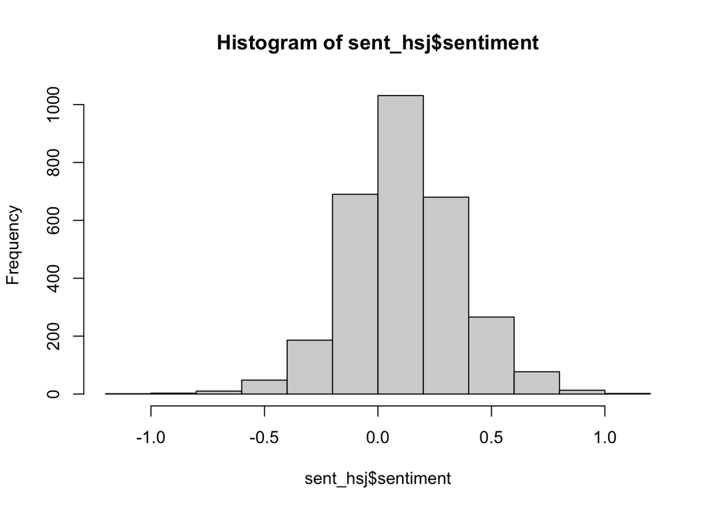

```r
hist(sent_hsj$sentiment)
```

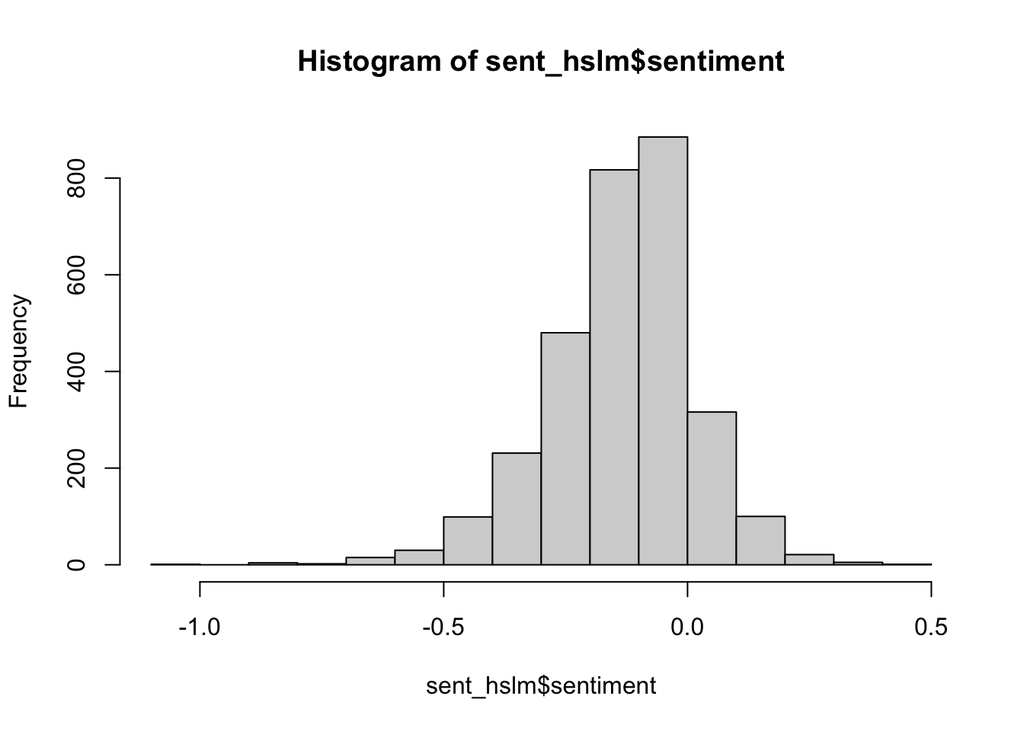

```r
hist(sent_hslm$sentiment)
```

Very neutral for the most part. Very few of them are overly positive or overly negative.

## Topic Models

```r
library(quanteda)
library(stringr)
library(stm)
library(tm)
#model_data <- combined_list
model_data <- text_list

model_data <- model_data %>%
  textclean::replace_contraction() %>%
  str_replace_all(., "\n", " ") %>%
  str_replace_all(., "(\\[.*?\\])", "") %>%
  str_squish() %>%
  gsub("([a-z])([A-Z])", "\\1 \\2", .) %>%
  tolower() %>%
  textstem::lemmatize_strings(.)


model_data1 <- model_data

Encoding(model_data1) <- "UTF-8"

# creates the corpus with document variables except for the "text"
text_corpus <- corpus(model_data1)

smart_words <- tm::stopwords("SMART")

text_token <- tokens(text_corpus,
                      remove_punct = TRUE,
                      remove_symbols = TRUE,
                      remove_numbers = TRUE) %>%
               tokens_remove(smart_words, padding = TRUE)

text_dfm <- dfm(text_token)

text_dfm <- dfm_trim(text_dfm, sparsity = 0.990)

text_stm <- convert(text_dfm, to = "stm")

docs_stm <- text_stm$documents
vocab_stm <- text_stm$vocab
meta_stm <- text_stm$meta

textPrep <- prepDocuments(documents = docs_stm,
                           vocab = vocab_stm,
                           meta = meta_stm)
```

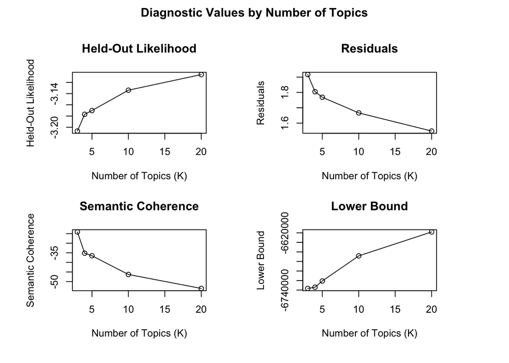

```r
kTest <- searchK(documents = textPrep$documents,
             vocab = textPrep$vocab,
             K = c(3, 4, 5, 10, 20), verbose = FALSE)

plot(kTest)
```

Let’s choose 5 topics, which balances both Semantic Coherence and Held Out Likelihood well. With our 5 topics, we can start our actual model:

```r
topics5 <- stm(documents = textPrep$documents,
             vocab = textPrep$vocab, seed = 1001,
             K = 5, verbose = FALSE)
```

We can get a lot of output from our model, but we can focus on the expected topic proportions plot:

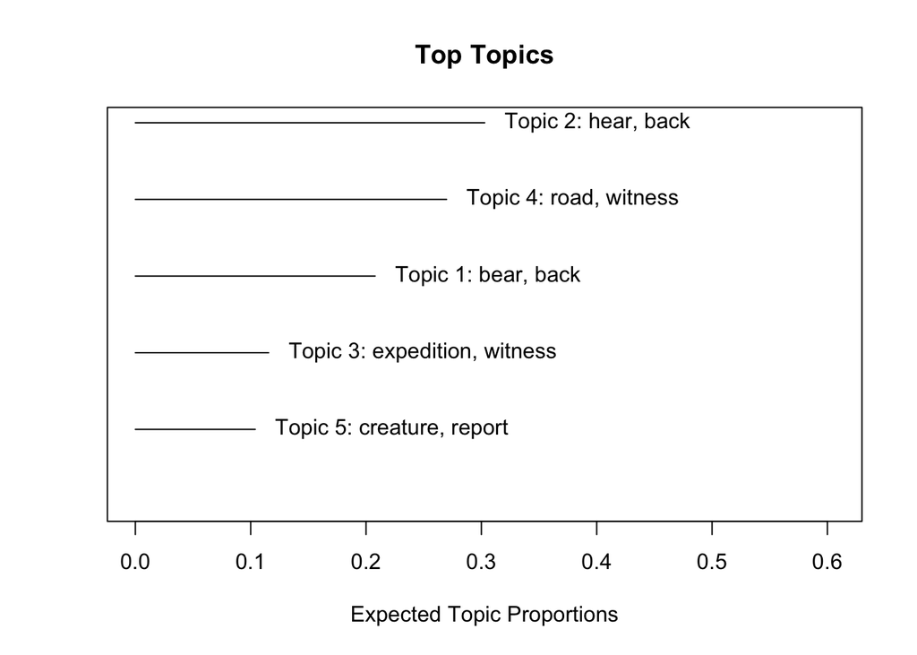

```r
plot(topics5)
```

We are essentially looking at the proportion of each topic, with a few of the highest probability words.

This is great, but it is really fun to see what emerges from the topics.

```r
labelTopics(topics5)
```

```
## Topic 1 Top Words:
##       Highest Prob: bear, back, walk, good, mountain, make
##       FREX: mountain, california, oregon, elk, ridge, didn, steep
##       Lift: na, footage, loop, pg, logger, ve, california
##       Score: na, mountain, california, trail, elk, hike
## Topic 2 Top Words:
##       Highest Prob: hear, back, wood, tree, run, sound
##       FREX: sound, dog, hear, house, loud, door, noise
##       Lift: bathroom, owl, stupid, bedroom, whistle, couch, tent
##       Score: house, stupid, hear, sound, dog, scream
## Topic 3 Top Words:
##       Highest Prob: expedition, witness, area, investigator, florida, tree
##       FREX: florida, michigan, expedition, organize, island, georgia, private
##       Lift: anthropology, author, political, woodknocks, cathy, todd, 1attended
##       Score: expedition, florida, accident, bc, vancouver, monteith, michigan
## Topic 4 Top Words:
##       Highest Prob: road, witness, county, sight, animal, creature
##       FREX: drive, illinois, road, cross, car, headlight, highway
##       Lift: gerard, oncoming, illinois, blog, clue, stan's, tony
##       Score: illinois, clue, road, stan's, motorist, blog, drive
## Topic 5 Top Words:
##       Highest Prob: creature, report, area, bigfoot, track, county
##       FREX: article, iowa, police, monster, mr, print, officer
##       Lift: authority, deputy, legendary, sheriff, article, sheriff's, dakota
##       Score: article, iowa, mrs, deputy, monster, sheriff, sheriff's
```

Let’s see which other words are most common.

```r
pun <- tm::removePunctuation(x = model_data1)

freq_x <- sort(table(unlist(strsplit(pun, " "))),      # Create frequency table
               decreasing = TRUE)
head(freq_x,100)
```

```
##
##        the         be                   and          a          i         to
##     150037     105017      78608      72510      68531      54116      52906
##         of         it         in       have       that         on         he
##      49009      46178      39183      31229      27591      24229      22735
##        see         at         my        not       this         we         as
##      20095      17914      17434      17150      16187      16068      15655
##      about       with       from    witness         by         up        but
##      15477      14720      12440      12168      11721      11577      11406
##        for         do      there       look       area       they       road
##      11316      10539      10437       9816       9772       9349       9120
##        can        his         or        out         go         me       when
##       8916       8888       8723       8423       8417       8189       8063
##       what       very   creature        she       like       back     county
##       8005       7824       7596       7546       7533       7487       7209
##       foot        say       just       time        get        one         no
##       7125       7001       6738       6730       6527       6466       6444
##       hear     report     animal       wood       walk         so      sight
##       6378       6236       5953       5902       5890       5757       5755
##        run     around       down       tree       much      would        its
##       5616       5550       5549       5533       5443       5354       5307
##       into      think      other        all        two       then      large
##       5101       5034       5020       4951       4912       4875       4816
##       come       year        her       side      where       over      stand
##       4711       4673       4546       4507       4505       4499       4436
##     follow      after       tell expedition       near       tall       know
##       4432       4378       4245       4230       4207       4128       4087
##      leave       hair        him      night       good       turn       head
##       4072       4049       4015       4014       3972       3965       3949
##       long       make
##       3947       3914
```

```r
freq_x <- data.frame(freq_x)

freq_x$Var1 <- as.character(freq_x$Var1)

stops <- paste("^",tm::stopwords("SMART"),"$", sep = "")


stops <- paste(stops, collapse = '|')

report <- freq_x$Var1  %>%
  grepl(stops, .)%>%
  which(. == TRUE)

freq_y <- freq_x[-c(report),]

head(freq_y,100)
```

|  | Var1 | Freq |
| --- | --- | --- |
| 3 |  | 78608 |
| 25 | witness | 12168 |
| 33 | area | 9772 |
| 35 | road | 9120 |
| 45 | creature | 7596 |
| 48 | back | 7487 |
| 49 | county | 7209 |
| 50 | foot | 7125 |
| 53 | time | 6730 |
| 57 | hear | 6378 |

[output cut: 90 more lines]

```r
library(tidytext)
library(stopwords)
```

```r
library(wordcloud2)
library(RColorBrewer)

pun <- data.frame(pun)

pun %>%
  dplyr::select(pun) %>%
    mutate(pun = as.character(pun),
         pun = str_replace_all(pun, "\n", " "),
         pun = str_replace_all(pun, "(\\[.*?\\])", ""),
         pun = str_squish(pun),
         pun = gsub("([a-z])([A-Z])", "\\1 \\2", pun)) %>%
  unnest_tokens(word, pun) %>%
  anti_join(stop_words) %>%
  count(word, sort = TRUE) %>%
  filter(n > 100) %>%
  na.omit() %>%
  wordcloud2(shape = "cardioid")
```

[interactive chart not shown]

## States Data

Find state names in the data and plot which states have the most occurences

```r
states <- tolower(state.name)

states_from_list <- str_extract(text_list, paste(state.name, collapse='|'))

state_frame <- data.frame(table(states_from_list))
```

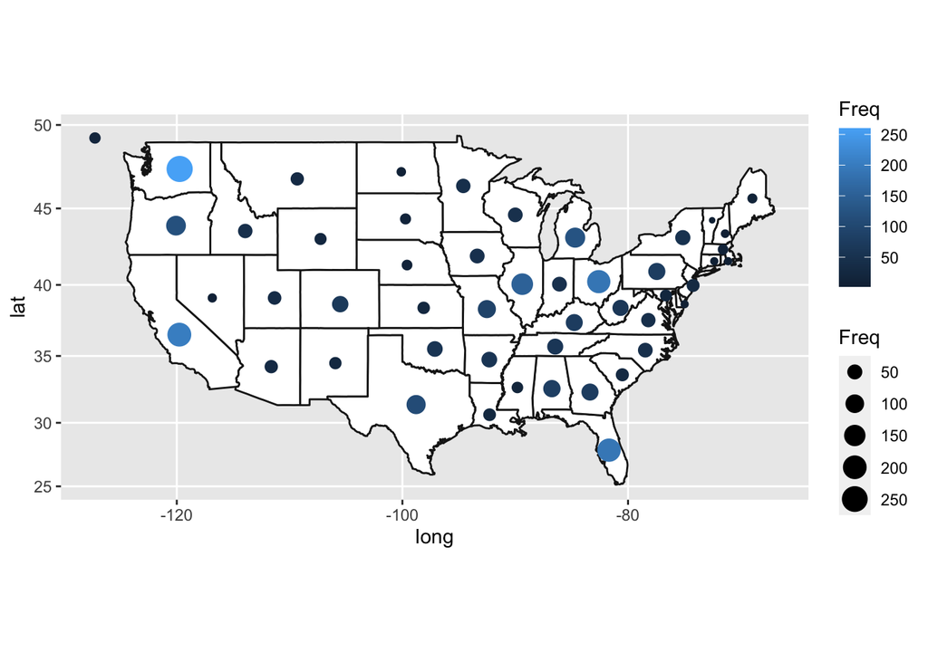

```r
library(ggplot2)
state_data <- map_data("state")


#need to drop Hawaii, which should be the 11th one
center <- data.frame(state.name, state.center)
center <- center[-c(11),]

state_info <- cbind(state_frame, center)

ggplot() +
  geom_polygon(data=state_data, aes(x=long, y=lat, group = group),colour="grey10", fill="white" ) +
  coord_map() +
  geom_point(data=state_info, aes(x=x,y=y, color = Freq, size=Freq))
```

The size of the circle represents the number of bigfoot sightings per state.

Let’s get some bear data and compare

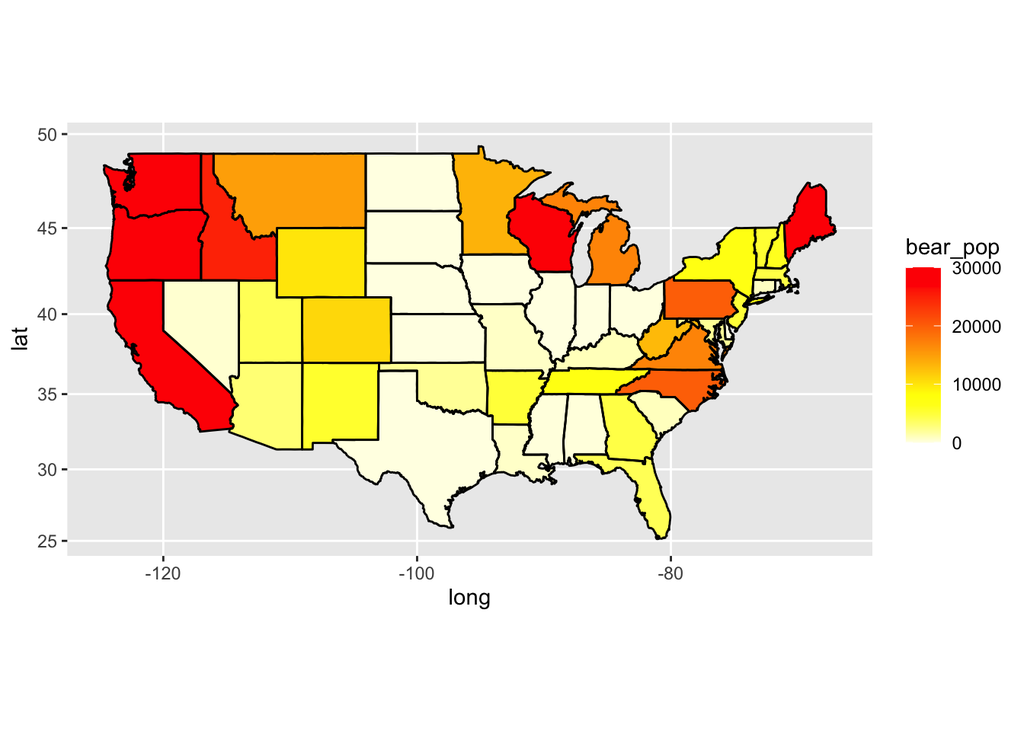

```r
library(ggplot2)
library(maps)

bear <- read_html("https://wildlifeinformer.com/black-bear-population-by-state/") %>%
 # html_text()
  html_table()  %>%
  `[[`(1)

bear$`Black Bear Population` <- gsub(",", "", bear$`Black Bear Population`)
bear$`Black Bear Population` <- gsub("none", "0", bear$`Black Bear Population`)
bear$`Black Bear Population` <- gsub("Low/rare sightings", "0", bear$`Black Bear Population`)
bear$`Black Bear Population` <- gsub("unknown/robust population", "10000", bear$`Black Bear Population`)
bear$`Black Bear Population` <- gsub("5-10 \\(new population\\)", "8", bear$`Black Bear Population`)
bear$`Black Bear Population` <- gsub("100-200", "150", bear$`Black Bear Population`)
bear$`Black Bear Population` <- gsub("24000-36000", "30000", bear$`Black Bear Population`)
bear$`Black Bear Population` <- gsub("540-840", "690", bear$`Black Bear Population`)
bear$`Black Bear Population` <- gsub("5000-6000", "5500", bear$`Black Bear Population`)
bear$`Black Bear Population` <- gsub("25000-30000", "27500", bear$`Black Bear Population`)
bear$`Black Bear Population` <- gsub("30-40", "35", bear$`Black Bear Population`)
bear$`Black Bear Population` <- gsub("24000-31000", "27500", bear$`Black Bear Population`)
bear$`Black Bear Population` <- gsub("6000-8000", "7000", bear$`Black Bear Population`)
bear$`Black Bear Population` <- gsub("4600-5700", "5300", bear$`Black Bear Population`)
bear$`Black Bear Population` <- gsub("4000-5000", "4500", bear$`Black Bear Population`)
bear$`Black Bear Population` <- gsub("15000-19000", "17000", bear$`Black Bear Population`)
bear$`Black Bear Population` <- gsub("12000-15000", "13500", bear$`Black Bear Population`)
bear$`Black Bear Population` <- gsub("10000-12000", "11000", bear$`Black Bear Population`)
bear$`Black Bear Population` <- gsub("20000-30000", "25000", bear$`Black Bear Population`)
bear$`Black Bear Population` <- gsub("500-750", "625", bear$`Black Bear Population`)
bear$`Black Bear Population` <- gsub("100-150", "125", bear$`Black Bear Population`)
bear$`Black Bear Population` <- gsub("300-500", "400", bear$`Black Bear Population`)
bear$`Black Bear Population` <- gsub("50-100", "75", bear$`Black Bear Population`)
bear$`Black Bear Population` <- gsub("12000-14000", "13000", bear$`Black Bear Population`)

bear$bear_pop <- as.integer(bear$`Black Bear Population`)
bear$region <- tolower(bear$`State Name`)

states <- map_data("state")
map.df <- merge(states,bear, by="region", all.x=T)
map.df <- map.df[order(map.df$order),]
ggplot(map.df, aes(x=long,y=lat,group=group))+
  geom_polygon(aes(fill=bear_pop))+
  geom_path()+
  scale_fill_gradientn(colours=rev(heat.colors(20)),na.value="grey90")+
  coord_map()
```

Bear and bigfoot on the same graph

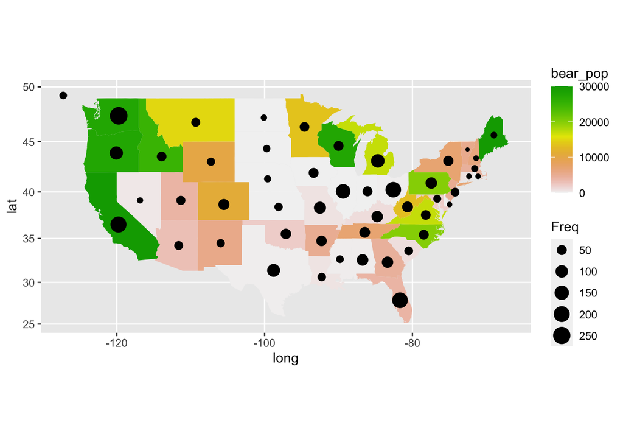

```r
ggplot() +
  geom_polygon(data=map.df, aes(x=long, y=lat, group = group, fill=bear_pop)) +
  geom_path() +
  scale_fill_gradientn(colours=rev(terrain.colors(20)),na.value="grey90") +
  coord_map() +
  geom_point(data=state_info, aes(x=x,y=y, size= Freq))
```

Not a ton of correlation for some states. Does not appear to be an excellent predictor.

## Text Complexity

Finally, let’s analyze the text complexity of our data using quanteda.

```r
library(quanteda)
library(quanteda.textstats)

combine_data <- text_list
Encoding(combine_data) <- "UTF-8"

# creates the corpus with document variables except for the "text"
combine_corpus <- corpus(combine_data)

combine_tokens <- tokens(combine_corpus)
dfmat_combine <- dfm(combine_tokens, remove = stopwords("en"))
tstat_lexdiv <- textstat_lexdiv(dfmat_combine)
tail(tstat_lexdiv, 5)
```

|  | document | TTR |
| --- | --- | --- |
| 3003 | text3003 | 0.7208589 |
| 3004 | text3004 | 0.6367925 |
| 3005 | text3005 | 0.7372093 |
| 3006 | text3006 | 0.6075731 |
| 3007 | text3007 | 0.6348039 |

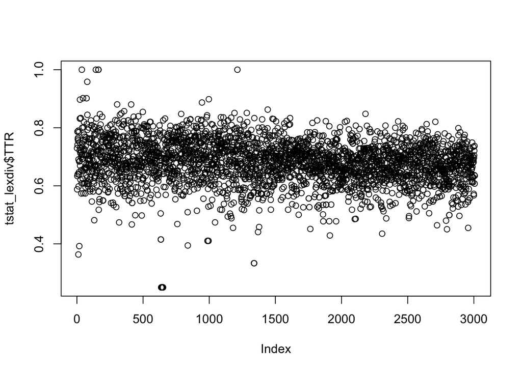

```r
plot(tstat_lexdiv$TTR)
```

Really is centered around the 0.7 or 70th percentile mark. These testimonies are more complex than average writing. Which is interesting considering the type of people who stereotypically are associated with bigfoot sightings.

## Other Testimonies Pulled

These are some additional testimonies pulled from the same website. However, each has much fewer reports and different writing styles that messed with the analytics.

Bigfoot Encounters Website

```r
b <- read_html("http://www.penn.freeservers.com/bigfootmaps/bfecreature.txt") %>%
  html_text()

bfec <- str_extract_all(b, ("[{]([^}]+)[}]"))
bfec <- bfec[[1]]
bfec <- gsub(pattern = "\\{URL=", replacement = "", x = bfec)
bfec <- gsub(pattern = "\\}", replacement = "", x = bfec)



text_list_bfec <- c()



for (i in 1:length(bfec)) {

if(i %% 15 == 0) {Sys.sleep(10)}
bf <- tryCatch(read_html(bfec[i]) %>%
 # html_text()
  html_table()  %>%
  `[[`(2), error = function(e) {NA})

bf <- as.character(bf)
bf <- gsub(pattern = "\r\n", replacement = "", x = bf)
bf <- gsub(pattern = "\\s+", replacement = " ", x = bf)
bf <- gsub(" REMOTE_HOST:", "", bf)
bf <- gsub("([a-z])([A-Z])", "\\1 \\2", bf)
bf <- gsub("([1-9])([A-Z])", "\\1 \\2", bf)
bf <- gsub("([a-z])([1-9])", "\\1 \\2", bf)
bf <- gsub(" REMOTE_ADDR:", "", bf)
bf <- gsub(" REMOTE_USER:", "", bf)
bf <- gsub(" Org Name:", "", bf)
bf <- gsub(" Org ID:", "", bf)
bf <- gsub('"', "'", bf)

text_list_bfec <- append(text_list_bfec, bf)

print(i)
}


save(text_list_bfec, file = "bfec.rda")

load(file = "bfec.rda")

head(text_list_bfec, 10)

#pull out the NAs
na_list <- which(is.na(text_list_bfec))
text_list_bfec <- text_list_bfec[-c(na_list)]
```

Scrape the Pennsylvania Bigfoot Society

```r
#PaBigfoot Society

c <- read_html("http://penn.freeservers.com/bigfootmaps/PBScreature.txt") %>%
  html_text()

bpa <- str_extract_all(c, ("[{]([^}]+)[}]"))
bpa <- bpa[[1]]
bpa <- gsub(pattern = "\\{URL=", replacement = "", x = bpa)
bpa <- gsub(pattern = "\\}", replacement = "", x = bpa)




text_list_bpa <- c()



for (i in 1:length(bpa)) {

if(i %% 15 == 0) {Sys.sleep(10)}
bp <- tryCatch(read_html(bpa[i]) %>%
 # html_text()
  html_table()  %>%
  `[[`(4), error = function(e) {NA})

bp <- as.character(bp)
bp <- gsub(pattern = "\\\\n", replacement = "", x = bp)
bp <- gsub(pattern = "\\s+", replacement = " ", x = bp)
bp <- gsub(pattern = "\\\\t", replacement = " ", x = bp)
bp <- gsub("([a-z])([1-9])", "\\1 \\2", bp)
bp <- gsub('"', "'", bp)
bp <- gsub("\\c\\(", "", bp)
bp <- gsub("\\)", "", bp)


text_list_bpa <- append(text_list_bpa, bp)

print(i)
}


save(text_list_bpa, file = "bpa.rda")


load(file = "bpa.rda")

#tail(text_list_bpa, 10)


#pull out the NAs
na_list <- which(is.na(text_list_bpa))
text_list_bpa <- text_list_bpa[-c(na_list)]
```

Ohio Sasquatch sightings - not working

```r
d <- read_html("http://penn.freeservers.com/bigfootmaps/EOBICcreature.txt") %>%
  html_text()

eoibc <- str_extract_all(d, ("[{]([^}]+)[}]"))

eoibc <- eoibc[[1]]
eoibc <- gsub(pattern = "\\{URL=", replacement = "", x = eoibc)
eoibc <- gsub(pattern = "\\}", replacement = "", x = eoibc)




text_list_eoibc <- c()



for (i in 1:length(eoibc)) {

if(i %% 15 == 0) {Sys.sleep(10)}
bc <- tryCatch(read_html(eoibc[i]) %>%
  html_elements("b") %>%
  html_text() %>%
  `[[`(1), error = function(e) {NA})

bc <- as.character(bc)
bc <- gsub(pattern = "\r\n", replacement = "", x = bc)
bc <- gsub(pattern = "\\s+", replacement = " ", x = bc)
bc <- gsub("([a-z])([A-Z])", "\\1 \\2", bc)



text_list_eoibc <- append(text_list_eoibc, bc)

print(i)
}


save(text_list_eoibc, file = "eoibc.rda")


load(file = "eoibc.rda")

head(text_list_eoibc, 20)


#pull out the NAs
na_list <- which(is.na(text_list_eoibc))
text_list_eoibc <- text_list_eoibc[-c(na_list)]
```

```r
#kentucky bigfoot society
e <- read_html("http://www.penn.freeservers.com/bigfootmaps/kbfcreature.txt") %>%
  html_text()

bks <- str_extract_all(e, ("[{]([^}]+)[}]"))
bks <- bks[[1]]
bks <- gsub(pattern = "\\{URL=", replacement = "", x = bks)
bks <- gsub(pattern = "\\}", replacement = "", x = bks)



text_list_bks <- c()



for (i in 1:length(bks)) {

if(i %% 15 == 0) {Sys.sleep(10)}
bk <- tryCatch(read_html(bks[i]) %>%
  html_elements("p") %>%
  html_text(), error = function(e) {NA})

bk <- as.character(bk)
bk <- toString(bk)

bk <- gsub(pattern = "\\\\n", replacement = "", x = bk)
bk <- gsub(pattern = "\\s+", replacement = " ", x = bk)
bk <- gsub('"', "'", bk)
bk <- gsub("Your first name:", ",", bk)
bk <- gsub("Which county?", ",", bk)
bk <- gsub("Estimated date?", ",", bk)
bk <- gsub("Estimated time?", ",", bk)
bk <- gsub("Nearest city?", ",", bk)
bk <- gsub("Nearest Road\\(s\\):", ",", bk)
bk <- gsub("Length of time the encounter lasted:", ",", bk)
bk <- gsub("How many witnesses?", ",", bk)
bk <- gsub("Any additional Info?", ",", bk)
bk <- gsub("Please describe your encounter:", ",", bk)
bk <- gsub("What city, or nearest city :", ",", bk)
bk <- gsub("--*--", "", bk)
bk <- gsub("\\?", "", bk)
bk <- gsub("Website submission", "", bk)
bk <- gsub("Website Submission", "", bk)
bk <- gsub(" 1\\. ", "", bk)
bk <- gsub(" 2\\. ", "", bk)
bk <- gsub(" 3\\. ", "", bk)
bk <- gsub(" 4\\. ", "", bk)
bk <- gsub(" 5\\. ", "", bk)
bk <- gsub(" 6\\. ", "", bk)
bk <- gsub(" 7\\. ", "", bk)
bk <- gsub(" 8\\. ", "", bk)
bk <- gsub("Submit Your Sighting.*", "", bk)
bk <- gsub(pattern = "\\s+", replacement = " ", x = bk)



text_list_bks <- append(text_list_bks, bk)

print(i)
}


save(text_list_bks, file = "bks.rda")


load(file = "bks.rda")

#head(text_list_bks, 20)


#pull out the NAs
na_list <- which(is.na(text_list_bks))
#text_list_bks <- text_list_bks[-c(na_list)]
```

```r
#oregon big foot

f <- read_html("http://penn.freeservers.com/bigfootmaps/obfcreature.txt") %>%
  html_text()

obs <- str_extract_all(f, ("[{]([^}]+)[}]"))
obs <- obs[[1]]
obs <- gsub(pattern = "\\{URL=", replacement = "", x = obs)
obs <- gsub(pattern = "\\}", replacement = "", x = obs)



text_list_obs <- c()



for (i in 1:length(obs)) {

if(i %% 15 == 0) {Sys.sleep(10)}
bs <- tryCatch(read_html(obs[i]) %>%
  html_elements("p") %>%
  html_text()  %>%
  `[[`(22), error = function(e) {NA})

bs <- as.character(bs)

bs <- gsub(pattern = "\r\n", replacement = "", x = bs)
bs <- gsub(pattern = "\\s+", replacement = " ", x = bs)
bs <- gsub('"', "'", bs)
bs <- gsub("Description of event: ", "", bs)



text_list_obs <- append(text_list_obs, bs)

print(i)
}


save(text_list_obs, file = "obs.rda")


load(file = "obs.rda")

#head(text_list_obs, 20)


#pull out the NAs
na_list <- which(is.na(text_list_obs))
#text_list_obs <- text_list_obs[-c(na_list)]
```

Combine all of the lists together

```r
combined_list <- c(text_list, text_list_bfec, text_list_bks, text_list_bpa, text_list_obs)

save(combined_list, file = "combined.rda")
#load(file = "combined.rda")
```